# Concurrent validity of an Estimator of Weekly Alcohol Consumption (EWAC) based on the Extended AUDIT

# 1 Introduction

Alcohol consumption is a significant cause of death and ill health. A number of strategies for prevention (PH24), treatment and harm reduction (CG115). Many of those rely on the use of a screening tool. In the UK, the reference tool is the Alcohol Use Disorders Identification Test (AUDIT) [1], a 10-item questionnaire schedule widely employed in clinical practice and clinical research as a diagnostic test for alcohol use disorder (ICD-10 F10.1/F10.2; ICD-11 QE10/6C40.1). The short, 3 consumption item version known as AUDIT-C has proven good predictive capabilities for both: (a) clinical diagnoses (e.g. Composite International Diagnostic Interview, Structured Clinical Interview, Alcohol Use Disorder and Associated Disabilities Interview); and (b) consumption in excess of maximum recommended intakes (e.g. 140g/week in Australia, 112 g/week in UK) in a variety of clinical and community dwelling populations [2].

A variant of the AUDIT-C schedule known as the ‘Extended AUDIT-C’ improves the granularity of the information collected on alcohol consumption, thanks to a greater range of response options in the quantity and frequency items (questions 1 and 2). The Extended AUDIT-C has been used in UK research as part of two trials [3] and the Alcohol Toolkit Study [5] to capture greater information on the higher risk drinkers, based on the observation that consumption items are right-truncated.

Neither the AUDIT-C nor the Extended AUDIT-C provide a measure of usual alcohol consumption, which could help individuals understand, monitor and adjust their drinking behaviour. Making individuals more aware of the consumption and associated risk is a key recommendation in the recent literature [6] and modern government alcohol policy guidelines [8].

The aim of the present study is develop and validate an Estimator of usual Weekly Alcohol Consumption in units (EWAC) based on the Extended AUDIT-C. The product of frequency of drinking (AUDIT-C item 1) and quantity of drinking (AUDIT-C item 2) can be used to estimate usual alcohol consumption. In addition, measures of heavy use (AUDIT-C item 3) have been found to improve the consistency of the estimator with other data sources in previous research [10].

This paper reports four distinct empirical studies. Study 1 estimates coefficients to apply to each of the AUDIT-C response items to compute an EWAC using data from a large English household survey, the Alcohol Toolkit Study (ATS). Using the same source, Study 2 models measures of deviation between the EWAC and alcohol consumption as estimated in the survey’s graduated-frequency schedule. This analysis seeks to identify measures of bias and variance in the EWAC under the assumption that the graduated-frequency schedule constitutes a gold-standard. Study 3 models the deviation between EWAC and another comparator from the 28-day Timeline Followback in a questionnaire study conducted amongst visitors of an acute hospital based in Southampton, UK. Finally, Study 4 compares the population-wide total and empirical cumulative distribution of alcohol consumption in England using the EWAC, the ATS graduated frequency schedule, the Health Survey for England, and official statistics on alcohol sales.

# 2 Methods

## 2.1 Overview of alcohol consumption estimation methods

A fundamental hindrance at the core of alcohol research and care is the absence of a measurement gold standard. A number of instruments exist which have been subjected to concurrent validity analysis instead. A state-of-the art review is available from [11] and summarised in the Table below

```r
read.csv("table_comparison_alco_schedules.csv") %>%
  kable %>%
  kable_styling()
```

[output not shown]

Broadly, WD tend to capture the highest alcohol consumption levels, followed by GF and the lowest levels are recorded by QF measures [12]. A large investigation conducted as part of the Health Survey for England (HSE) [14] compared a WD with an interview-based specific-beverage QF method underpinning the UK national statistics on alcohol consumption. The authors found consistent mean weekly drinking estimates in the two methods, with most differences being associated with drink type and venue.

## 2.2 Study 1: Concurrent consistency with Graduated Frequency in England

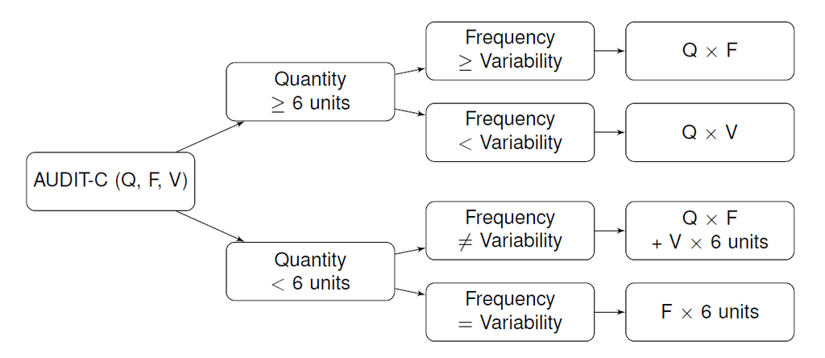

Quantity-Frequency-Variability estimator overview (adapted from [10])

To replicate this approach, we determine weights to be applied to each Extended AUDIT-C response item in order to compute the EWAC.

- using the AUDIT-C response item interval midpoint: for example, 2 to 3 times per week is set to 2.5 times per week
- using a statistical model to estimate the coefficients directly from the data. Missing data in the GF schedule (14.7% of participants giving a non-‘Never’ answer to the AUDIT-C item 1) is assumed to be missing at random conditionally on the Extended AUDIT-C responses. We employ a Bayesian hierarchical fitted in STAN setting uniform priors on the value of each AUDIT-C item. Detail is available in supplementary materials.

Next, we quantify the deviation between the EWAC and the GF schedule. A pre-registered protocol for this analysis is available from [15]. Succintly, this analysis treats GF like a gold standard. It enables the examination of two types of deviations across every participant $i$ in the ATS sample:

- MD: the mean deviation
  $$\sum_{i=1}^{n}{n^{-1}(\rm{EWAC_i} - \rm{GF_i} )}$$
  can be assimilated to a measure of bias under the assumption that GF is a gold standard.
- RMSD: the root mean squared deviation
  $$\sum_{i}{\sqrt{( \rm{EWAC_i} - \rm{GF_i} )^2}}$$
  can be assimilated to a measure of total error: it capture both bias and random deviation from the gold standard.

## 2.3 Study 2:

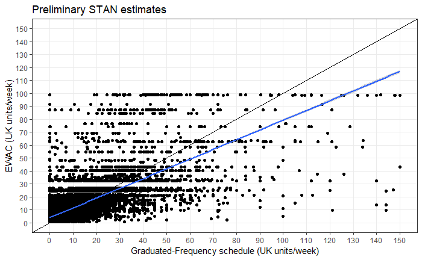

## 2.4 Aggregate comparison with ONS schedule and alcohol sales data

# 3 Results

```r
lm1 <- lm((ewac_v3-gfmeanweekly)  ~ ageg*sex + favdrink + ethgrp, data = ats)
lm1 <- lm((ewac_v3-gfmeanweekly)  ~ ageg*sex + favdrink + ethgrp, data = ats)
summary(lm1)
```

```
Call:
lm(formula = (ewac_v3 - gfmeanweekly) ~ ageg * sex + favdrink +
    ethgrp, data = ats)

Residuals:
    Min      1Q  Median      3Q     Max
-366.24   -4.70   -0.01    4.67   93.56

Coefficients:
                             Estimate Std. Error t value Pr(>|t|)
(Intercept)                   4.53618    1.66145   2.730  0.00634 **
ageg25-34 years              -1.71592    0.92998  -1.845  0.06505 .
ageg35-44 years              -1.66001    0.92071  -1.803  0.07142 .
ageg45-54 years               0.01236    0.88751   0.014  0.98889
ageg55-64 years               2.12623    0.93760   2.268  0.02337 *
ageg65-74 years               0.66922    1.10414   0.606  0.54446
ageg75-84 years               3.56689    2.00971   1.775  0.07596 .
ageg85 years and over         6.85577    4.19224   1.635  0.10201
sexMen                       -1.49574    0.82030  -1.823  0.06827 .
favdrinkCider                -1.38789    0.77456  -1.792  0.07319 .
favdrinkMixed spirits         0.89516    0.74757   1.197  0.23117
favdrinkOther                 3.84056    1.96000   1.959  0.05009 .
favdrinkSpirits alone         0.52252    0.64681   0.808  0.41920
favdrinkWine                  1.07114    0.41880   2.558  0.01055 *
ethgrpBlack                   2.93236    2.12766   1.378  0.16817
ethgrpMixed                  -3.22872    2.07722  -1.554  0.12013
ethgrpOther                   4.15303    2.85278   1.456  0.14548
ethgrpWhite British          -1.82679    1.52115  -1.201  0.22981
ethgrpWhite Other            -0.07979    1.68295  -0.047  0.96219
ageg25-34 years:sexMen        0.82236    1.19168   0.690  0.49016
ageg35-44 years:sexMen       -0.09221    1.17966  -0.078  0.93770
ageg45-54 years:sexMen       -0.64346    1.11018  -0.580  0.56220
ageg55-64 years:sexMen       -0.88836    1.14269  -0.777  0.43692
ageg65-74 years:sexMen        2.79124    1.29403   2.157  0.03103 *
ageg75-84 years:sexMen       -0.09711    2.24780  -0.043  0.96554
ageg85 years and over:sexMen -4.20092    4.78455  -0.878  0.37996
---
Signif. codes:  0 ‘***’ 0.001 ‘**’ 0.01 ‘*’ 0.05 ‘.’ 0.1 ‘ ’ 1

Residual standard error: 16.05 on 9877 degrees of freedom
  (30177 observations deleted due to missingness)
Multiple R-squared:  0.01691,   Adjusted R-squared:  0.01442
F-statistic: 6.794 on 25 and 9877 DF,  p-value: < 2.2e-16
```

```r
lm1 <- lm(sqrt((ewac_v3-gfmeanweekly)^2) ~ ageg*sex + favdrink + ethgrp, data = ats)
summary(lm1)
```

```
Call:
lm(formula = sqrt((ewac_v3 - gfmeanweekly)^2) ~ ageg * sex +
    favdrink + ethgrp, data = ats)

Residuals:
   Min     1Q Median     3Q    Max
-14.13  -6.51  -3.61   1.20 356.79

Coefficients:
                             Estimate Std. Error t value Pr(>|t|)
(Intercept)                    7.0440     1.4143   4.981 6.45e-07 ***
ageg25-34 years               -0.3489     0.7916  -0.441 0.659406
ageg35-44 years                1.5302     0.7837   1.952 0.050911 .
ageg45-54 years                1.3023     0.7555   1.724 0.084777 .
ageg55-64 years                2.7564     0.7981   3.454 0.000556 ***
ageg65-74 years                2.0622     0.9399   2.194 0.028252 *
ageg75-84 years                2.5715     1.7107   1.503 0.132832
ageg85 years and over          6.0345     3.5686   1.691 0.090866 .
sexMen                         1.6987     0.6983   2.433 0.015002 *
favdrinkCider                  0.6261     0.6593   0.950 0.342354
favdrinkMixed spirits         -1.0757     0.6364  -1.690 0.090995 .
favdrinkOther                 -0.6039     1.6684  -0.362 0.717403
favdrinkSpirits alone          1.4309     0.5506   2.599 0.009369 **
favdrinkWine                  -0.6891     0.3565  -1.933 0.053280 .
ethgrpBlack                    1.6967     1.8112   0.937 0.348884
ethgrpMixed                    1.2660     1.7682   0.716 0.474015
ethgrpOther                    1.0095     2.4284   0.416 0.677647
ethgrpWhite British           -0.1727     1.2949  -0.133 0.893871
ethgrpWhite Other              0.2724     1.4326   0.190 0.849208
ageg25-34 years:sexMen        -0.3386     1.0144  -0.334 0.738575
ageg35-44 years:sexMen        -0.6693     1.0042  -0.666 0.505108
ageg45-54 years:sexMen        -0.5603     0.9450  -0.593 0.553273
ageg55-64 years:sexMen        -0.7253     0.9727  -0.746 0.455877
ageg65-74 years:sexMen         0.6897     1.1015   0.626 0.531260
ageg75-84 years:sexMen        -1.7711     1.9134  -0.926 0.354675
ageg85 years and over:sexMen  -1.1025     4.0728  -0.271 0.786633
---
Signif. codes:  0 ‘***’ 0.001 ‘**’ 0.01 ‘*’ 0.05 ‘.’ 0.1 ‘ ’ 1

Residual standard error: 13.66 on 9877 degrees of freedom
  (30177 observations deleted due to missingness)
Multiple R-squared:  0.01242,   Adjusted R-squared:  0.009925
F-statistic:  4.97 on 25 and 9877 DF,  p-value: 5.045e-15
```

# 4 Discussion

- GF not missing at random. Impute the 14.8% missing cases

The three sources of information used in this validation measure different constructs: the HSE quantity-frequency does not capture variability, whereas the HSE weekly diary and the ATS graduated frequency schedule do. The HSE diary should nevertheless exhibit smaller recall error.

This paper adopted a QFV approach to compute the EWAC over arguably more direct approaches possible with the ATS, such as supervised machine learning or direct estimation of the mean alcohol consumption for every observed combination of Extended AUDIT-C responses. Although cumbersome, the deterministic nature of the QFV algorithm is meant to be easier to estimate with small training datasets. It is also easier to implement in relational databases employed in electronic record systems compared to many manchine learning techniques.

## 4.1 Limitations

Findings reported in this paper only concern adult residents of private households in England, and may not generalise to other countries or age groups. The ATS is a computer-assisted personal interview survey, which may improve data quality for the Extended AUDIT compared with, for instance, a self-administered Extended AUDIT in a health care context. During data collection, we recorded a frequent confusion with the AUDIT’s item 1: some participants being confused as to whether the question refers to number of days in which alcohol has been consumed, or number of occasions on any given day. We believe this to be a common occurrence when the AUDIT is self-administered.

# 5 Tables

Table 1: Overview of alcohol schedule used in this paper.

Survey module

Schedule

- On how many days, if any, did you personally drink a drink containing alcohol in the last four weeks?
- What was the maximum number of units you personally consumed on any one day when drinking an alcoholic drink or drinks in the last four weeks?
- On how many days, if any, in the last four weeks did you personally drink… [prompting in turn ‘51-60 units?’, ‘41-50 units?’, …, '1-2 units?

*Health Survey for England*

- Thinking now about all kinds of drinks, how often have you had an alcoholic drink of any kind during the last 12 months? *[8 items from ‘Almost every day’ to ‘Not at all in the last 12 months’]*
- Did you have an alcoholic drink in the seven days ending yesterday?
- On how many days out of the last seven did you have an alcoholic drink?
- Which day last week did you last have an alcoholic drink/have the most to drink?
- Thinking about last [answer to previous question], what types of drink did you have that day? [list of 8 types of alcohol beverages]
- [running through each type of beverage and recording number of units drunk]

# 6 References

[1] Babor TF, Higgins-Biddle JC, Saunders JB, Monteiro MG. The Alcohol Use Disorders Identification Test. Guidelines for Use in Primary Care. Second Edition. Geneva: World Health Organisation, Department of Mental Health; Substance Dependence; 2001.

[2] Meneses-Gaya C de, Zuardi AW, Loureiro SR, Crippa JAS. Alcohol Use Disorders Identification Test (AUDIT): An updated systematic review of psychometric properties. Psychology & Neuroscience 2009;2:83–97. doi:10.3922/j.psns.2009.1.12.

[3] Kaner E, Bland M, Cassidy P, Coulton S, Dale V, Deluca P, et al. Effectiveness of screening and brief alcohol intervention in primary care (SIPS trial): pragmatic cluster randomised controlled trial. BMJ 2013;346:e8501–1. doi:10.1136/bmj.e8501.

[4] Crane D, Garnett C, Michie S, West R, Brown J. A smartphone app to reduce excessive alcohol consumption: Identifying the effectiveness of intervention components in a factorial randomised control trial. Scientific Reports 2018;8:4384. doi:10.1038/s41598-018-22420-8.

[5] Beard E, Brown J, West R, Acton C, Brennan A, Drummond C, et al. Protocol for a national monthly survey of alcohol use in England with 6-month follow-up: ’The Alcohol Toolkit Study’ Health behavior, health promotion and society. BMC Public Health 2015;15. doi:10.1186/s12889-015-1542-7.

[6] Nutt DJ, Rehm J. Doing it by numbers: A simple approach to reducing the harms of alcohol. Journal of Psychopharmacology 2014;28:3–7. doi:10.1177/0269881113512038.

[7] Rehm J, Anderson P, Manthey J, Shield KD, Struzzo P, Wojnar M, et al. Alcohol Use Disorders in Primary Health Care: What Do We Know and Where Do We Go? Alcohol and Alcoholism 2016;51:422–7. doi:10.1093/alcalc/agv127.

[8] Australian Government. National Health and Medical Research Council. Australian Guidelines to Reduce Health Risks from Drinking Alcohol. 2009.

[9] UK Department of Health. UK Chief Medical Officers’ Low Risk Drinking Guidelines. August 2016. 2016.

[10] Lemmens P, Tan ES, Knibbe R a. Measuring quantity and frequency of drinking in a general population survey: a comparison of five indices. Journal of Studies on Alcohol 1992;53:476–86. doi:10.15288/jsa.1992.53.476.

[11] Greenfield TK. Ways of measuring drinking patterns and the difference they make: experience with graduated frequencies. Journal of Substance Abuse 2000;12:33–49. doi:10.1016/S0899-3289(00)00039-0.

[12] Heeb J-L, Gmel G. Measuring alcohol consumption: A comparison of graduated frequency, quantity frequency, and weekly recall diary methods in a general population survey. Addictive Behaviors 2005;30:403–13. doi:10.1016/j.addbeh.2004.04.022.

[13] Rehm J. Measuring Quantity, Frequency, and Volume of Drinking. Alcoholism: Clinical and Experimental Research 1998;22:4s–14s. doi:10.1111/j.1530-0277.1998.tb04368.x.

[14] Boniface S, Kneale J, Shelton N. Drinking pattern is more strongly associated with under-reporting of alcohol consumption than socio-demographic factors: evidence from a mixed-methods study. BMC Public Health 2014;14:1297. doi:10.1186/1471-2458-14-1297.

[15] Dutey-Magni P, Sinclair J, Brown J. Concurrent validity of an estimator of weekly alcohol consumption (ewac) based on the extended audit 2018. doi:10.17605/OSF.IO/7WE4M.